# Bayesian Modeling with RJAGS

## Calculating posterior predictions

We just explored the posterior trend in weight $Y$ among adults with height $X = 180$: $m_{180} = a+ b \times 180$. The `weight_chains` data frame contains $100,000$ posterior plausible values of $m_{180}$ that we calculated from the corresponding values of $a$ and $b$:

```r
head(weight_chains, 2)
```

A data.frame: 2 × 4

|  | a <dbl> | b <dbl> | s <dbl> | m_180 <dbl> |
| --- | --- | --- | --- | --- |
| 1 | -106.5042 | 1.027620 | 9.053909 | 78.46745 |
| 2 | -106.6708 | 1.029252 | 9.159864 | 78.59459 |

Forget the trend - what if we wanted to predict the weight of a specific $180$ cm tall adult? We can! To do so, we must account for individual variability from the trend, modeled by: $$Y_{180} \sim N(m_{180}, s^2)$$

Using this model, we will simulate predictions of weight under each set of posterior plausible parameters in `weight_chains`.

```r
# Simulate 1 prediction under the first parameter set
rnorm(n = 1, mean = weight_chains$m_180[1], sd = weight_chains$s[1])

# Simulate 1 prediction under the second parameter set
rnorm(n = 1, mean = weight_chains$m_180[2], sd = weight_chains$s[2])

# Simulate & store 1 prediction under each parameter set
weight_chains <- weight_chains  %>%
    mutate(Y_180 = rnorm(n = 100000, mean = m_180, sd = s))

# Print the first 6 parameter sets & predictions
head(weight_chains)
```

91.9321804998788

73.7239952043041

A data.frame: 6 × 5

|  | a <dbl> | b <dbl> | s <dbl> | m_180 <dbl> | Y_180 <dbl> |
| --- | --- | --- | --- | --- | --- |
| 1 | -106.5042 | 1.027620 | 9.053909 | 78.46745 | 82.34302 |
| 2 | -106.6708 | 1.029252 | 9.159864 | 78.59459 | 80.85521 |
| 3 | -106.5268 | 1.026147 | 9.441036 | 78.17955 | 93.29745 |
| 4 | -106.1365 | 1.023241 | 9.607720 | 78.04680 | 101.73144 |
| 5 | -106.0383 | 1.027861 | 9.274800 | 78.97676 | 80.57684 |
| 6 | -107.2631 | 1.031626 | 9.155143 | 78.42966 | 59.58965 |

We now have $100,000$ predictions for the weight of a $180$ cm tall adult that reflect the range of posterior plausible parameter settings.

## Posterior predictive distribution

The `weight_chains` data frame contains our $100,000$ posterior predictions, `Y_180`, for the weight of a $180$ cm tall adult. We will use these $100,000$ predictions to approximate the **posterior predictive distribution** for the weight of a $180$ cm tall adult.

**2.5%**

59.6556624430282

**97.5%**

96.6225315146826

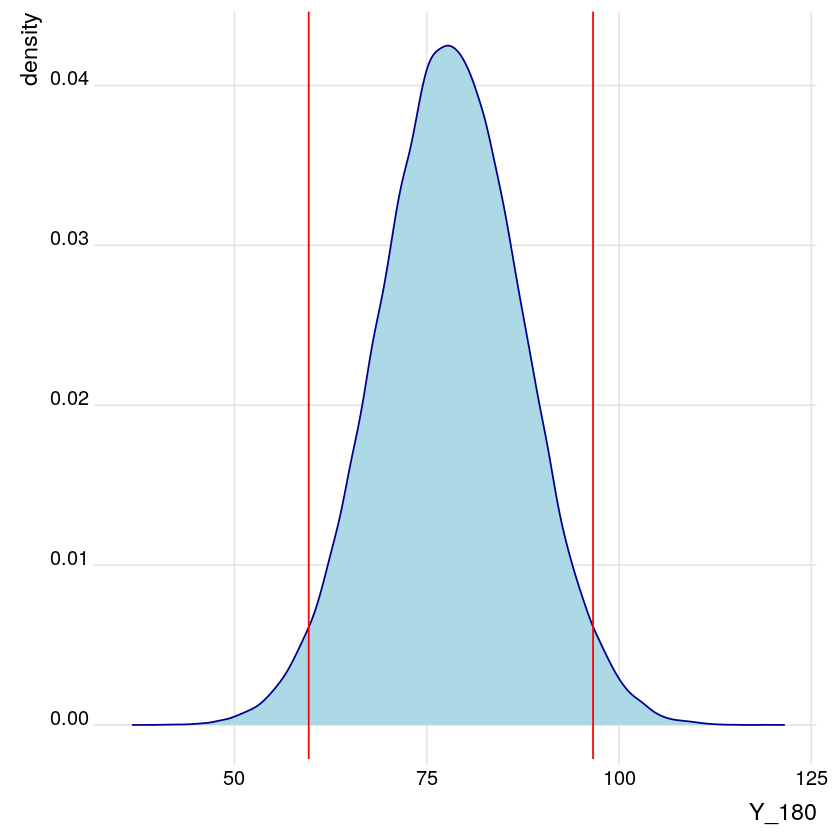

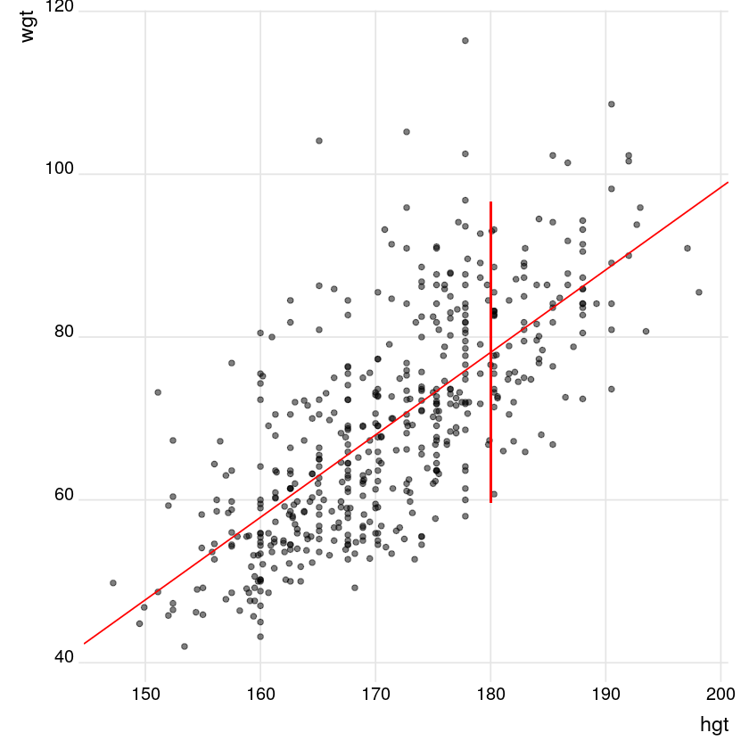

```r
# Construct a 95% posterior credible interval for the prediction
ci_180 <- quantile(weight_chains$Y_180, probs = c(0.025, 0.975))
ci_180

# Construct a density plot of the posterior predictions
ggplot(weight_chains, aes(x = Y_180)) +
    geom_density(color='darkblue', fill = 'lightblue') +
    geom_vline(xintercept = ci_180, color = "red") +
    theme_ridges()

# Visualize the credible interval on a scatterplot of the data
ggplot(bdims, aes(x = hgt, y = wgt)) +
    geom_point(alpha=0.5) +
    geom_abline(intercept = mean(weight_chains$a), slope = mean(weight_chains$b), color = "red") +
    geom_segment(x = 180, xend = 180, y = ci_180[1], yend = ci_180[2], color = "red") +
    theme_ridges()
```

# Bayesian regression with a categorical predictor

## Modeling volume by weekday

- $Y_i$ = trail volume (# of users) on day $i$
- $X_i$ = $1$ for weekdays, $0$ for weekends

**Model**

- $Y_i \sim N(m, s^2)$
- $m_i = a + bX_i$
- $a$ = typical weekend volume
- $a + b$ = typical weekday volume
- $b$ = contrast between typical weekday vs weekend volume
- $s$ = residual standard deviation

**Priors for $a$, $b$ & $s$**

- $Y_i \sim N(m , s^2)$
- $m_i = a + bX_i$
- $a$: Typical weekend volume is most likely around $400$ users per day, but possibly as low as $100$ or as high as $700$ users.
  - $a \sim N(400, 100^2)$
- $b$: We lack certainty about how weekday volume compares to weekend volume. It could be more, it could be less.
  - $b \sim N(0, 200^2)$
- $s$: The standard deviation in volume from day to day (whether on weekdays orweekends) is equally likely to be anywhere between $0$ and $200$ users.
  - $s \sim Unif (0, 200)$

## RailTrail sample data

The `RailTrail` data frame from the `mosaic` package contains data collected by the Pioneer Valley Planning Commission on the usage of a local rail-trail. For each of $90$ days, they recorded the rail-trail volume (number of users) and whether it was a weekday (TRUE if yes and FALSE otherwise). We will explore the trends in weekday vs weekend volume.

'factor'

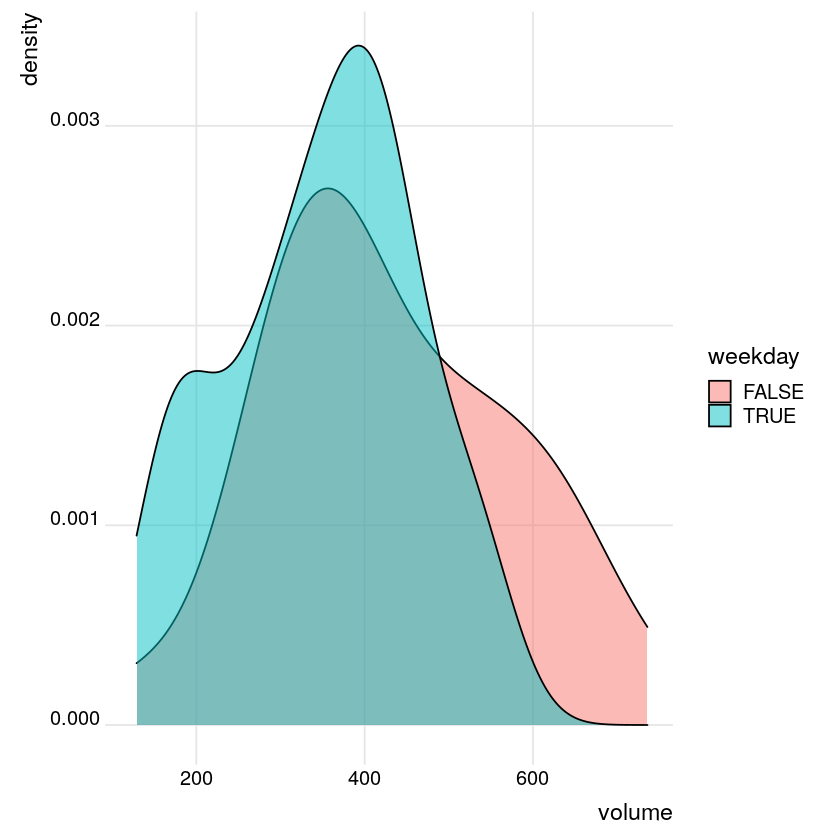

```r
data(RailTrail)

# Covert weekday to factor variable
RailTrail$weekday=as.factor(RailTrail$weekday)

# Confirm that weekday is a factor variable
class(RailTrail$weekday)

# Construct a density plot of volume by weekday
ggplot(RailTrail, aes(x = volume, fill = weekday)) +
    geom_density(alpha = 0.5) +
    theme_ridges()
```

Notice that, rail-trail volume tends to be slightly higher on weekends ($\sim 430$ users per day) than on weekdays ($\sim 350$ users per day).

## RJAGS simulation with categorical variables

Consider the Normal regression model of volume $Y_i$ by weekday status $X_i$:

- **likelihood:** $Y_i \sim N(m_i, s^2)$ where $m_i = a + bX_i$
- **priors:** $a \sim N(400,100^2)$, $b \sim N(0,200^2)$, $s \sim Unif(0,200)$

We explored the relationship between $Y_i$ and $X_i$ for the $90$ days recorded in `RailTrail`. In light of these data and the priors above, we will update our posterior model of this relationship. This differs from previous analyses in that $X_i$ is categorical. In **rjags** syntax, its coefficient $b$ is defined by two elements, `b[1]` and `b[2]`, which correspond to the weekend and weekday levels, respectively. For reference, `b[1]` is set to $0$. In contrast, `b[2]` is modeled by the prior for $b$.

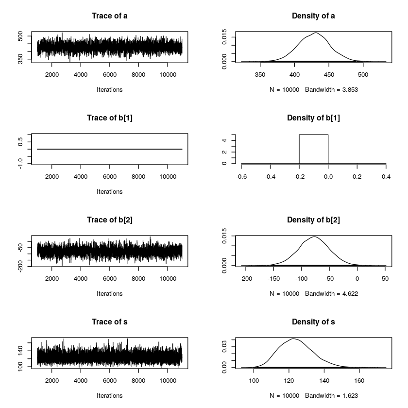

```r
# DEFINE the model
rail_model_1 <- "model{
    # Likelihood model for Y[i]
    for(i in 1:length(Y)){
      Y[i] ~ dnorm(m[i], s^(-2))
      m[i] <- a + b[X[i]]
    }

    # Prior models for a, b, s
    a ~ dnorm(400, 100^(-2))
    b[1] <- 0
    b[2] ~ dnorm(0, 200^(-2))
    s ~ dunif(0, 200)
}"

# COMPILE the model
rail_jags_1 <- jags.model(textConnection(rail_model_1),
  data = list(Y = RailTrail$volume, X = RailTrail$weekday),
  inits = list(.RNG.name = "base::Wichmann-Hill", .RNG.seed = 10)
)

# SIMULATE the posterior
rail_sim_1 <- coda.samples(model = rail_jags_1, variable.names = c("a", "b", "s"), n.iter = 10000)

# Store the chains in a data frame
rail_chains_1 <- data.frame(rail_sim_1[[1]])

# PLOT the posterior
plot(rail_sim_1)
```

We've successfully defined, compiled, and simulated a Bayesian regression model with a categorical predictor.

## Interpreting categorical coefficients

In our Bayesian model, $m_i = a + bX_i$ specified the dependence of typical trail volume on weekday status $X_i$ ($1$ for weekdays and $0$ for weekends). A `summary()` of your **RJAGS** model simulation provides posterior mean estimates of parameters $a$ and $b$, the latter corresponding to `b.2.` here.

```r
summary(rail_sim_1)
```

```
Iterations = 1001:11000
Thinning interval = 1
Number of chains = 1
Sample size per chain = 10000

1. Empirical mean and standard deviation for each variable,
   plus standard error of the mean:

       Mean     SD Naive SE Time-series SE
a    428.47 23.052  0.23052         0.5321
b[1]   0.00  0.000  0.00000         0.0000
b[2] -77.78 27.900  0.27900         0.6422
s    124.25  9.662  0.09662         0.1335

2. Quantiles for each variable:

       2.5%   25%    50%    75%  97.5%
a     383.1 412.9 428.78 443.62 474.20
b[1]    0.0   0.0   0.00   0.00   0.00
b[2] -133.2 -96.3 -77.65 -59.43 -23.07
s     107.5 117.3 123.59 130.32 144.90
```

Typically, there are $428.47$ trail users on a weekend day and $77.78$ fewer users ($\sim 350.69$) on a weekday.

### Inference for volume by weekday

```r
head(rail_chains_1, 2)
```

A data.frame: 2 × 4

|  | a <dbl> | b.1. <dbl> | b.2. <dbl> | s <dbl> |
| --- | --- | --- | --- | --- |
| 1 | 420.6966 | 0 | -54.30783 | 118.2328 |
| 2 | 399.5823 | 0 | -52.02570 | 119.9499 |

These chains provide $10,000$ unique sets of values for $a$, the typical trail volume on *weekend* days, and `b.2.`, the **contrast** between typical weekday volume vs weekend volume. For example, the first set of parameters indicate that there are typically $420.6966$ riders on weekend days and $54.30783$ fewer riders on weekdays. Thus there are typically $420.6966 - 54.30783 = 366.3888$ riders on weekdays. We will utilize these simulation data to make inferences about weekday trail volume.

**2.5%**

318.952028596343

**97.5%**

381.757301338758

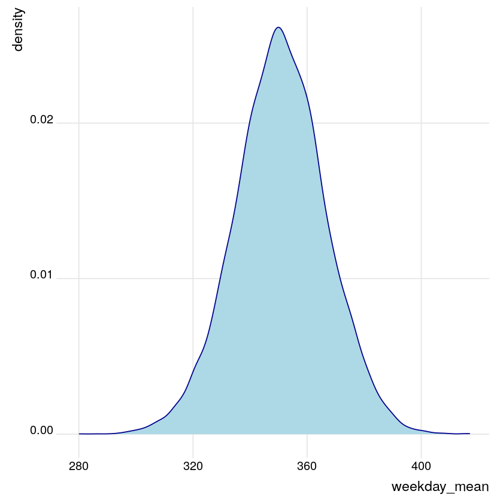

```r
# Construct a chain of values for the typical weekday volume
rail_chains_1 <- rail_chains_1 %>%
    mutate(weekday_mean = a + b.2.)

# Construct a density plot of the weekday chain
ggplot(rail_chains_1, aes(x = weekday_mean)) +
    geom_density(color='darkblue', fill = 'lightblue') +
    theme_ridges()

# 95% credible interval for typical weekday volume
quantile(rail_chains_1$weekday_mean, c(0.025, 0.975))
```

We've shown that there's a $95\%$ posterior chance that the typical weekday volume is between $319$ and $382$ trail users.

# Multivariate Bayesian regression

## Modeling volume by temperature & weekday

- $Y_i$ = trail volume (# of users) on day $i$
- $X_i$ = $1$ for weekdays, $0$ for weekends
- $Z_i$ = high temperature on day $i$ (in $^{\circ}$F)
- $Y_i \sim N(m_i , s^2)$
- $m_i = a + bX_i + cZ_i$
- **Weekends:** $m_i = a + cZ_i$
- **Weekdays:** $m_i = (a + b) + cZ_i$
- $a$ = weekend y-intercept
- $a + b$ = weekday y-intercept
- $b$ = contrast between weekday vs weekend y-intercepts
- $c$ = common slope
- $s$ = residual standard deviation

**Priors for $a$, $b$, $c$ & $s$**

- $Y_i \sim N(m_i , s^2)$
- $m_i = a + bX_i + cZ_i$
- We lack certainty about the y-intercept for the relationship between temperature & *weekend* volume.
  - $a \sim N(0, 200^2)$
- We lack certainty about how typical volume compares on weekdays vs weekends of similar temperature.
  - $b \sim N(0, 200^2)$
- Whether on weekdays or weekends, we lack certainty about the association between trail volume & temperature.
  - $c \sim N(0, 20^2)$
- The typical deviation from the trend is equally likely to be anywhere between $0$ and $200$ users.
  - $s \sim Unif (0, 200)$

# Re-examining the RailTrail data

In our previous work, we observed that rail-trail volume tends to be lower on a weekday than a weekend. Some of the variability in volume might also be explained by outside temperature. For example, we might expect trail volume to increase on warm, pleasant days.

The `RailTrail` data set includes hightemp, the observed high temperature ($^{\circ}$F) for each of the $90$ days in the study period. We will use these data to explore the associations between trail volume, weekday status, and hightemp

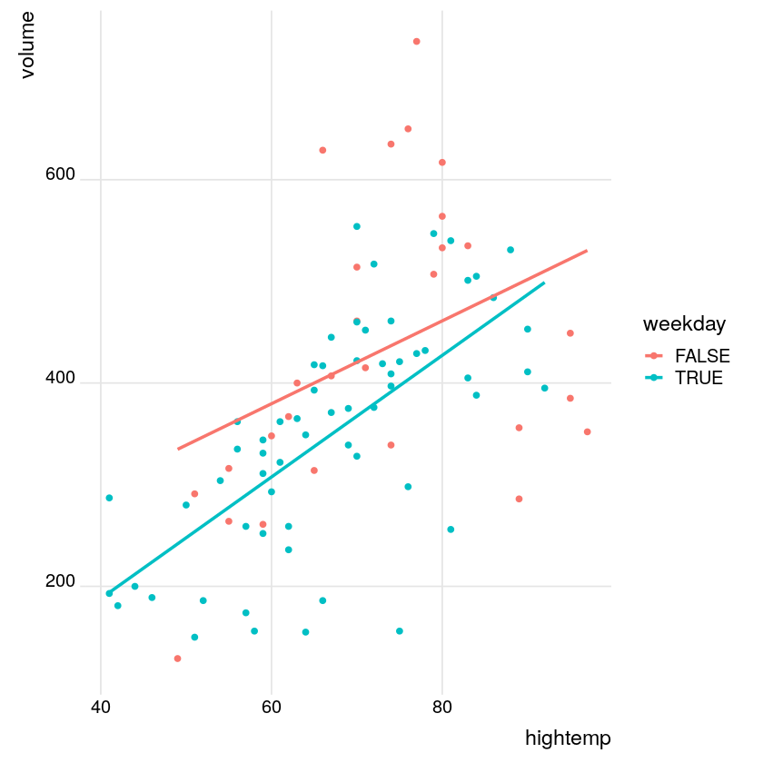

```r
# Construct a plot of volume by hightemp & weekday
ggplot(RailTrail, aes(y = volume, x = hightemp, color = weekday)) +
    geom_point() +
    geom_smooth(method = "lm", se = FALSE) +
    theme_ridges()
```

Notice that for the $90$ days in the study period, volume tends to increase with temperature. Further, volume tends to be higher on weekends than on weekdays of the same temperature.

## RJAGS simulation for multivariate regression

Consider the following Bayesian model of volume $Y_i$ by weekday status $X_i$ and temperature $Z_i$:

- **likelihood:** $Y_i ∼N(m_i, s^2)$ where $m_i = a + bX_i +cZ_i$.
- **priors:** $a \sim N(0,200^2)$, $b \sim N(0,200^2)$, $c \sim N(0,20^2)$, $s \sim Unif(0,200)$

Our previous exploration of the relationship between volume, weekday, and hightemp in the `RailTrail` data provided some insight into this relationship. We will combine this with insight from the priors to develop a posterior model of this relationship using **RJAGS**.

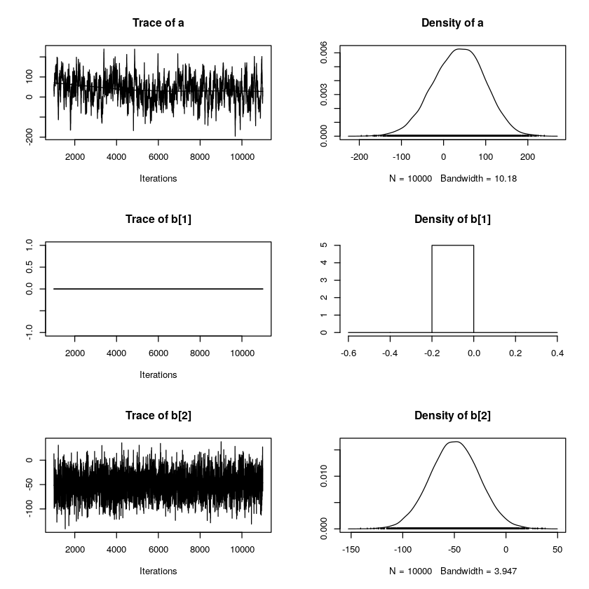

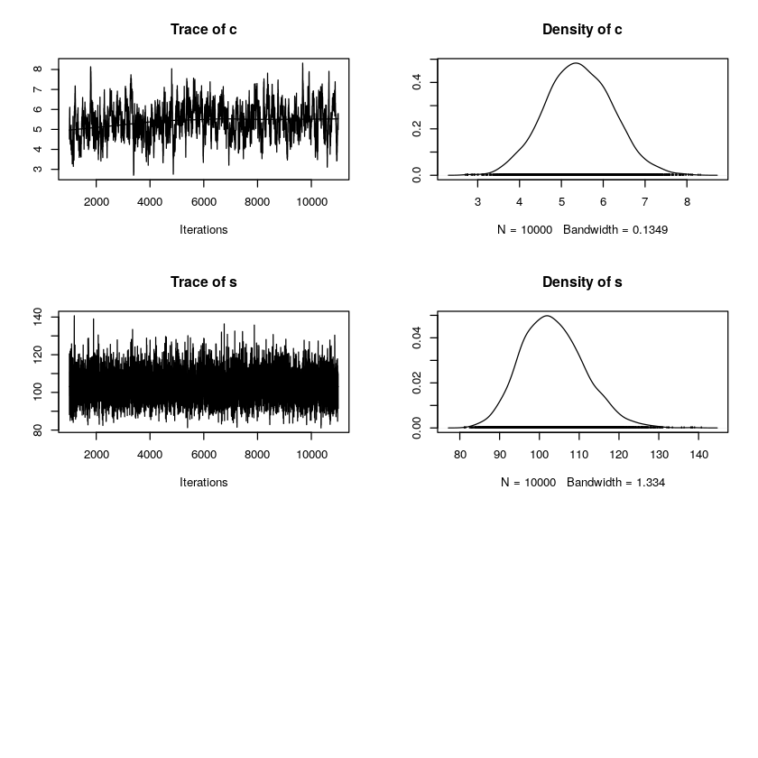

```r
# DEFINE the model
rail_model_2 <- "model{
# Likelihood model for Y[i]
for(i in 1:length(Y)) {
Y[i] ~ dnorm(m[i], s^(-2))
m[i] <- a + b[X[i]] + c * Z[i]
}
# Prior models for a, b, c, s
a ~ dnorm(0, 200^(-2))
b[1] <- 0
b[2] ~ dnorm(0, 200^(-2))
c ~ dnorm(0, 20^(-2))
s ~ dunif(0, 200)
}"

# COMPILE the model
rail_jags_2 <- jags.model(textConnection(rail_model_2),
    data = list(Y = RailTrail$volume, X = RailTrail$weekday, Z = RailTrail$hightemp),
    inits = list(.RNG.name = "base::Wichmann-Hill", .RNG.seed = 10))

# SIMULATE the posterior
rail_sim_2 <- coda.samples(model = rail_jags_2, variable.names = c("a", "b", "c", "s"), n.iter = 10000)

# Store the chains in a data frame
rail_chains_2 <- data.frame(rail_sim_2[[1]])

# PLOT the posterior
plot(rail_sim_2)
```

## Interpreting multivariate regression parameters

Our Bayesian model explored the dependence of typical trail volume on weekday status $X_i$ and temperature $Z_i$: $m_i = a + bX_i + cZ_i$. A `summary()` of our **RJAGS** model simulation provides posterior mean estimates of parameters $a$, $b$, and $c$:

```r
summary(rail_sim_2)
```

```
Iterations = 1001:11000
Thinning interval = 1
Number of chains = 1
Sample size per chain = 10000

1. Empirical mean and standard deviation for each variable,
   plus standard error of the mean:

        Mean      SD Naive SE Time-series SE
a     36.592 60.6238 0.606238        4.19442
b[1]   0.000  0.0000 0.000000        0.00000
b[2] -49.610 23.4930 0.234930        0.55520
c      5.417  0.8029 0.008029        0.05849
s    103.434  7.9418 0.079418        0.11032

2. Quantiles for each variable:

        2.5%     25%     50%     75%   97.5%
a    -83.443  -4.631  38.160  78.413 150.306
b[1]   0.000   0.000   0.000   0.000   0.000
b[2] -96.181 -65.468 -49.547 -33.633  -3.644
c      3.865   4.865   5.402   5.965   7.007
s     89.466  97.766 102.875 108.503 120.205
```

The posterior mean of $c$ indicates that for both weekends and weekdays, typical rail volume increases by $\sim 5.4$ users for every $1$ degree increase in temperature. The $b$ coefficient represents typical volume is $\sim 50$ less on weekdays than on weekends of the same temperature.

## Posterior inference for multivariate regression

The $10,000$ iteration **RJAGS** simulation output, `rail_sim_2` is a data frame of the Markov chain output:

```r
head(rail_chains_2, 2)
```

A data.frame: 2 × 5

|  | a <dbl> | b.1. <dbl> | b.2. <dbl> | c <dbl> | s <dbl> |
| --- | --- | --- | --- | --- | --- |
| 1 | 49.76954 | 0 | -12.62112 | 4.999202 | 111.02247 |
| 2 | 30.22211 | 0 | -3.16221 | 4.853491 | 98.11892 |

We will use these $10,000$ unique sets of parameter values to summarize the posterior mean trend in the relationships between trail volume, weekday status, and hightemp.

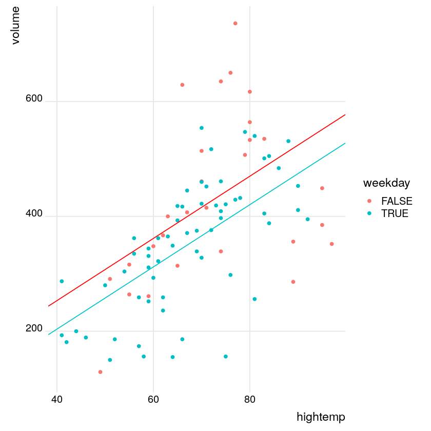

```r
# Plot the posterior mean regression models
ggplot(RailTrail, aes(y = volume, x = hightemp, color = weekday)) +
    geom_point() +
    geom_abline(intercept = mean(rail_chains_2$a), slope = mean(rail_chains_2$c), color = "red") +
    geom_abline(intercept = mean(rail_chains_2$a) + mean(rail_chains_2$b.2.), slope = mean(rail_chains_2$c),
                color = "turquoise3") +
    theme_ridges()
```

Our posterior analysis suggests that there's a positive association between volume and temperature. Further, the typical weekday volume is less than that on weekends of the same temperature.

# Poisson regression

**Normal likelihood structure**

- $Y$ = volume (# of users) on a given day
- $Y \sim N(m, s^2)$

**Technically...**

- The Normal model assumes $Y$ has a continuous scale and can be negative.
- But $Y$ is a discrete count and cannot be negative.

## The Poisson model

- $Y$ = volume (# of users) on a given day
- $Y \sim Pois(l)$
- Y is the # of independent events that occur in a fixed interval $(0, 1, 2,\dots)$.
- Rate parameter $l$ represents the typical # of events per time interval ($l > 0$).

### Poisson regression

- $Y_i \sim Pois(l_i)$ where $l_i > 0$
- $log(l_i) = a + bX_i + cZ_i$

**A solution:**

- Linking $l_i$ directly to the linear model assumes $l_i$ can be negative, so we use a log link function to link $l_i$ to the linear model. **In turn:**

$$l_i = e^{a+bX_i +cZ_i}$$

**Mathematical Notation:**

- $Y_i \sim Pois(l_i)$
- $log(l_i ) = a + bX_i + cZ_i$
- $a \sim N(0, 200^2)$
- $b \sim N(0, 2^2)$
- $c \sim N(0, 2^2)$

**Caveats:**

- $Y \sim Pois(l_i)$
- Assumption: Among days with similar temperatures and weekday status, variance in $Y_i$ is equal to the mean of $Y_i$.
- Our data demonstrate potential **over-dispersion** - the variance is larger than the mean.
- Though not perfect, this model is an OK place to start.

# RJAGS simulation for Poisson regression

Previously we engineered a Poisson regression model of volume $Y_i$ by weekday status $X_i$ and temperature $Z_i$:

- **likelihood:** $Y_i \sim Pois(l_i)$ where $log(l_i) = a + bX_i +cZ_i$
- **priors:** $a \sim N(0,200^2)$, $b \sim N(0,2^2)$, and $c \sim N(0,2^2)$

Combining our insights from the observed RailTrail data and the priors stated here, we will define, compile, and simulate a posterior model of this relationship using **RJAGS**.

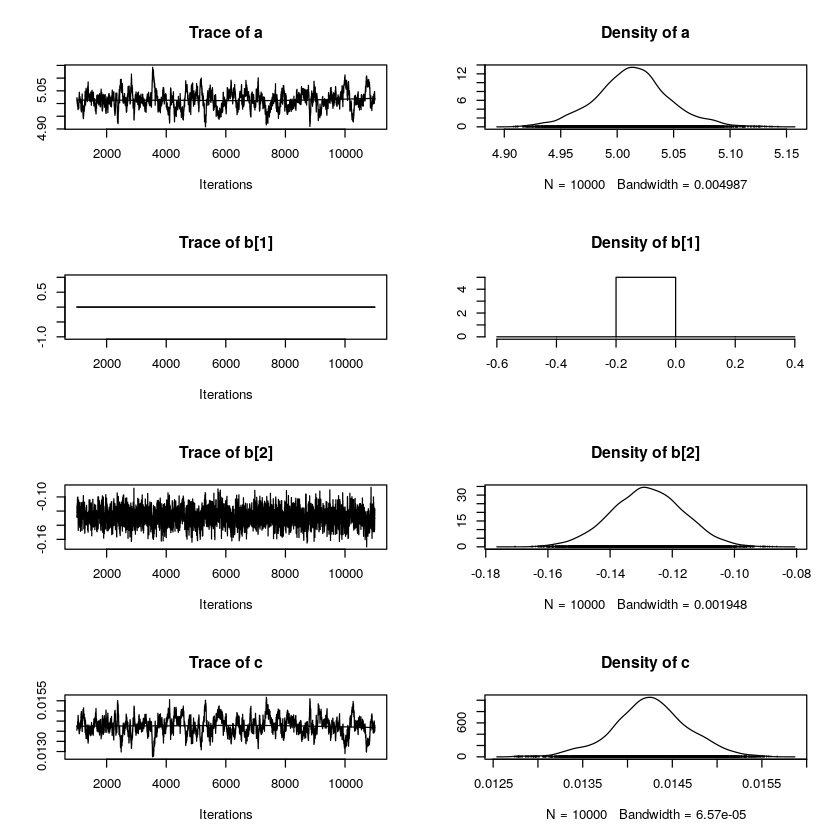

```r
# DEFINE the model
poisson_model <- "model{
# Likelihood model for Y[i]
for(i in 1:length(Y)) {
Y[i] ~ dpois(l[i])
log(l[i]) <- a + b[X[i]] + c*Z[i]
}
# Prior models for a, b, c
a ~ dnorm(0, 200^(-2))
b[1] <- 0
b[2] ~ dnorm(0, 2^(-2))
c ~ dnorm(0, 2^(-2))
}"

# COMPILE the model
poisson_jags <- jags.model(
  textConnection(poisson_model),
  data = list(Y = RailTrail$volume, X = RailTrail$weekday, Z = RailTrail$hightemp),
  inits = list(.RNG.name = "base::Wichmann-Hill", .RNG.seed = 10)
)

# SIMULATE the posterior
poisson_sim <- coda.samples(model = poisson_jags, variable.names = c("a", "b", "c"), n.iter = 10000)

# Store the chains in a data frame
poisson_chains <- data.frame(poisson_sim[[1]])

# PLOT the posterior
plot(poisson_sim)
```

## Plotting the Poisson regression model

Recall the likelihood structure for our Bayesian Poisson regression model of volume $Y_i$ by weekday status $X_i$ and temperature $Z_i$: $Y_i \sim Pois(l_i)$ where,

- $log(l_i) = a + bX_i + cZ_i$; thus
- $l_i = exp(a + bX_i + cZ_i)$

Our $10,000$ iteration **RJAGS** simulation of the model posterior, `poisson_sim`, is a data frame of the Markov chain output:

```r
head(poisson_chains, 2)
```

A data.frame: 2 × 4

|  | a <dbl> | b.1. <dbl> | b.2. <dbl> | c <dbl> |
| --- | --- | --- | --- | --- |
| 1 | 5.019807 | 0 | -0.1222143 | 0.01405269 |
| 2 | 5.018642 | 0 | -0.1217608 | 0.01407691 |

We will use these results to plot the posterior Poisson regression trends. These nonlinear trends can be added to a `ggplot()` using `stat_function()`.

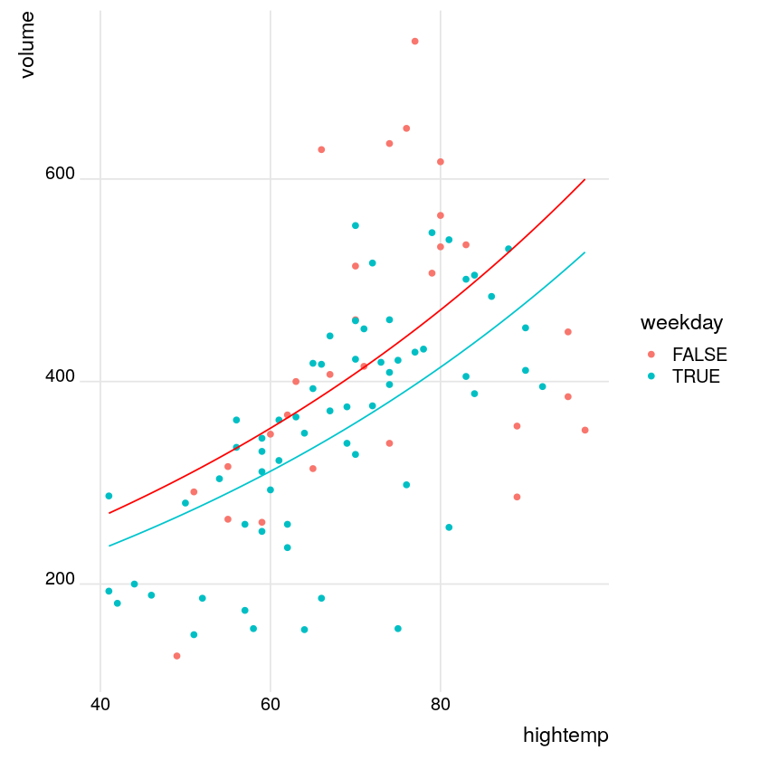

```r
# Plot the posterior mean regression models
ggplot(RailTrail, aes(x = hightemp, y = volume, color = weekday)) +
    geom_point() +
    stat_function(fun = function(x){exp(mean(poisson_chains$a) + mean(poisson_chains$c) * x)}, color = "red") +
    stat_function(fun = function(x){exp(mean(poisson_chains$a) + mean(poisson_chains$b.2.) +
                                        mean(poisson_chains$c) * x)}, color = "turquoise3") +
                                        theme_ridges()
```

Notice that unlike the Normal regression trend, the Poisson regression trend is *curved*.

## Inference for the Poisson rate parameter

We will make inferences about the typical trail volume on $80$ degree days.

```r
# Calculate the typical volume on 80 degree weekends & 80 degree weekdays
poisson_chains <- poisson_chains %>%
    mutate(l_weekend = exp(a + c * 80)) %>%
    mutate(l_weekday = exp(a + b.2. + c * 80))

# Construct a 95% CI for typical volume on 80 degree weekend
quantile(poisson_chains$l_weekend, c(0.025, 0.975))

# Construct a 95% CI for typical volume on 80 degree weekday
quantile(poisson_chains$l_weekday, c(0.025, 0.975))
```

**2.5%**

462.143134922169

**97.5%**

479.310055712039

**2.5%**

407.464368507052

**97.5%**

420.710174980761

## Poisson posterior prediction

Our `l_weekday` variable reflects the *trend* in volume on $80$ degree weekdays:

```r
head(poisson_chains, 2)
```

A data.frame: 2 × 6

|  | a <dbl> | b.1. <dbl> | b.2. <dbl> | c <dbl> | l_weekend <dbl> | l_weekday <dbl> |
| --- | --- | --- | --- | --- | --- | --- |
| 1 | 5.019807 | 0 | -0.1222143 | 0.01405269 | 465.9240 | 412.3235 |
| 2 | 5.018642 | 0 | -0.1217608 | 0.01407691 | 466.2839 | 412.8292 |

Now that we understand the *trend*, let's make some predictions. Specifically, let's *predict* trail volumes on the next $80$ degree weekday. To do so, we must take into account individual variability from the *trend*, modeled by the likelihood $Y_i \sim Pois(l_i)$.

Using `rpois(n, lambda)` for sample size $n$ and rate parameter $\text{lambda}$, we will simulate Poisson predictions of volume under each value of the posterior plausible trend in `poisson_chains`.

0.2419

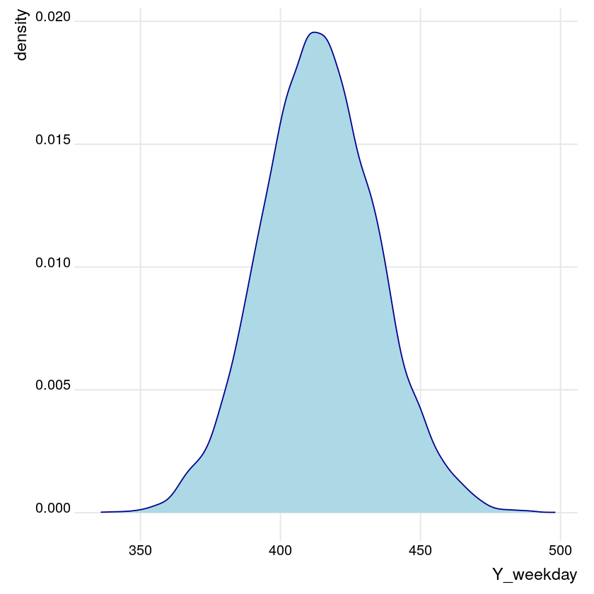

```r
# Simulate weekday predictions under each parameter set
poisson_chains <- poisson_chains %>%
    mutate(Y_weekday = rpois(n = 10000, lambda = l_weekday))

# Construct a density plot of the posterior weekday predictions
ggplot(poisson_chains, aes(x = Y_weekday)) +
    geom_density(color='darkblue', fill = 'lightblue') +
    theme_ridges()

# Posterior probability that weekday volume is less 400
mean(poisson_chains$Y_weekday < 400)
```

Recall that one of our motivations in applying the Poisson model was to accommodate the count nature of the volume data. This trickled down to our volume predictions `Y_weekday` - notice that these predictions, like the raw volume data, are discrete counts.